# CX survey report

Nundehui Xicotencatl

May 22, 2020

# About the project

The following report describes the responses from a customer experience survey, focused on the sales department. The questionary asks the general opinion about car-buying experience and three particular moments of interaction between the client (the respondent) and the dealership team (payment, delivery, after sales).

# About the dataset

The data for this project comes from a unique csv file which includes general data to identify the location, the consultant, the department, date, product sold, among others, and the items from the questionary regarding the expected behaviors when dealing with a client. From the results, it is expected to define training needs and establish sales and service bonuses and awards.

# General opinion

The database processed corresponds to more than 30k of surveys (23k service, 7k sales). The patterns are similar, most of the respondents assigned the highest score to its experience. To have a clear view of this, the same data using percentages relative to its total are presented on the right.

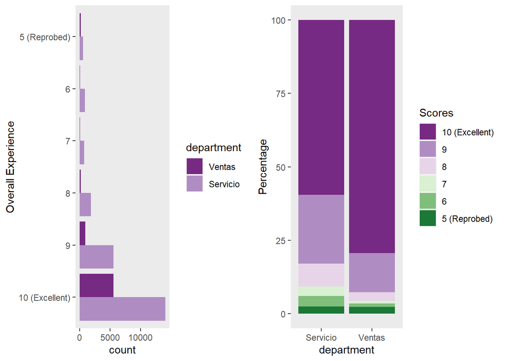

From an inspection from the further comments regarding the overall experience, the customers mostly used words such as “excelente” (excellent, around 2k times), “bien” (good, less than 1.5k) and “atencion” (support, less than 2k). The words at the cloud corresponds to the frequency of the most used words.

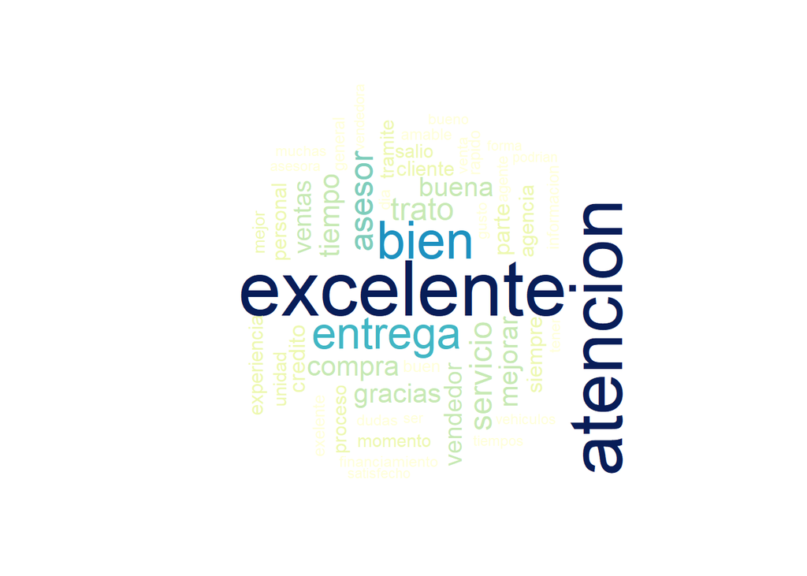

# Individual surveys

From the overall experience, interacting with the main contact person in the dealership is paramount. The perception towards this, is shown in the following graphs.

The customers refered to be treated politely and helpful. Less than 300 people complained about the personal interaction with the employees, being the poor product knowledge the one that received a negative opinion.

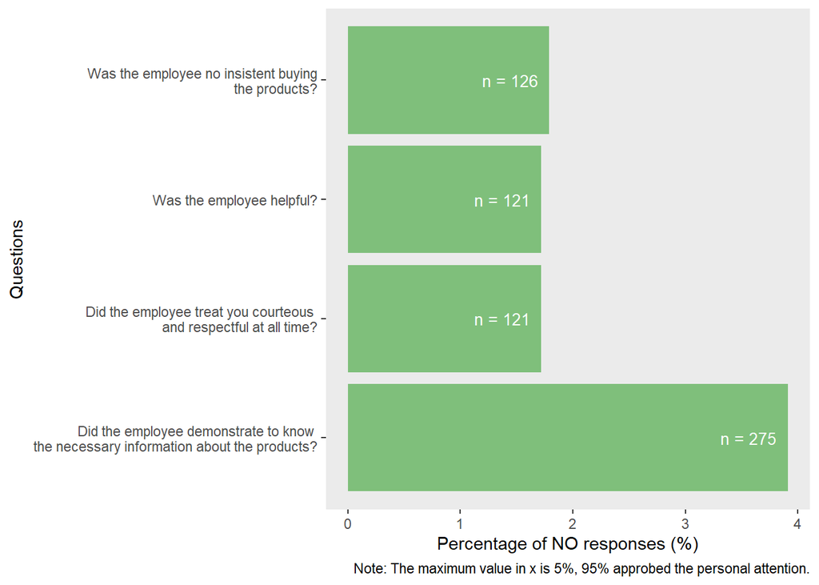

# Payment, delivery and after-sales

Buying a car faces three further moments at the firm. This part of the report will focus on them, showing the general perception towards each and which steps make them pleasant and satisfactory.

# Payment experience

Above 75% from the respondents refered to be extremely satisfied with the payment experience and less that 4% pointed the low quality of it.

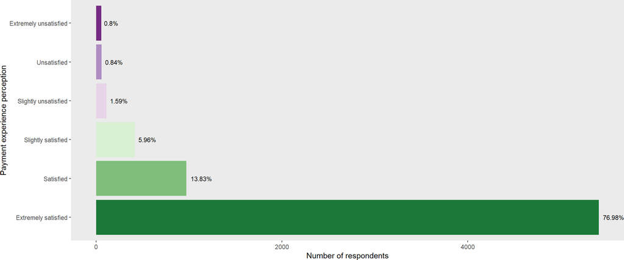

In table below, the number of negative comments regarding the payment experience are displayed. According to this, the time to deliver the documents is insufficient and there is a lack to understand the contract.

| **Characteristic** | **N = 7029**<sup>1</sup> |
| --- | --- |
| financial_products_info | 238 (3.4%) |
| payment_assistance | 297 (4.2%) |
| contract_explanation | 361 (5.1%) |
| time_for_docs | 548 (7.8%) |

<sup>*1*</sup> Statistics presented: n (%)

In an effort to go deeper on the complaints, a descriptive analysis of those who add further comments to this section on the survey was conducted. Using this results is possible to observe that negative opinions talk about “credito”, “precio”, “entrega”, “enganche” and “pagar” (credit, price, deliver, deposit and payment, respectively).

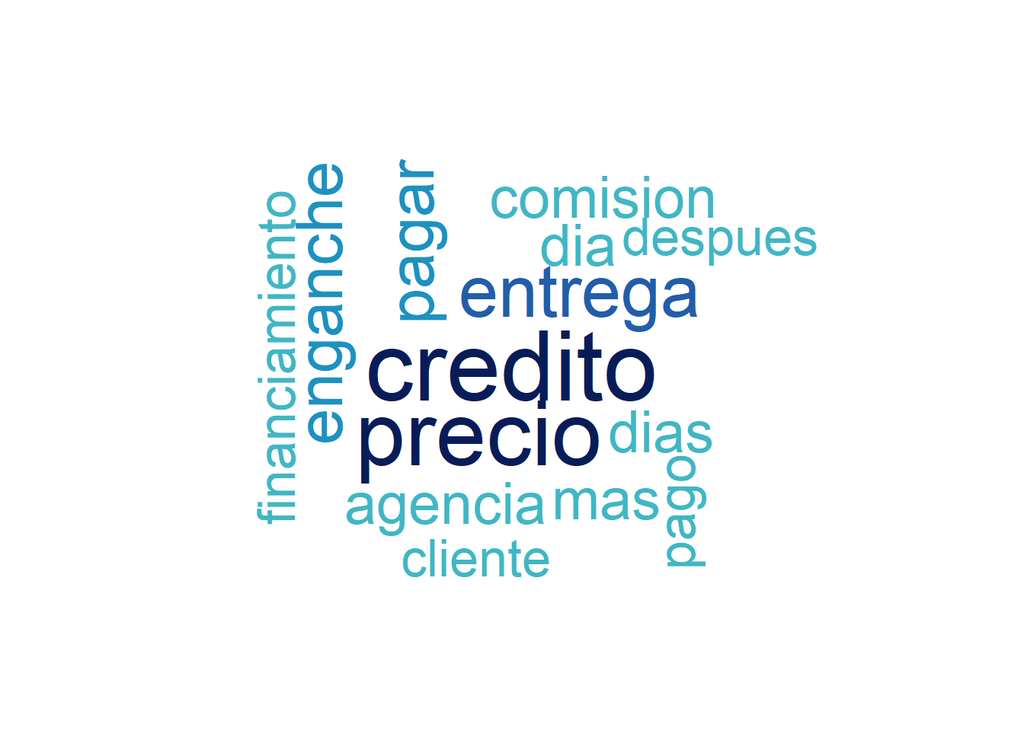

Interestingly, an analysis of the frequency of a 2 n-gram (appearance of word sequences) highlight similar complaints about “comision apertura”.

```
##                       n2
## comision apertura      5
## cambiaron condiciones  2
## dia siguiente          2
## dieron precio          2
## dijeron q              2
## historial crediticio   2
## meses intereses        2
## semana media           2
## tardo mas              2
## tasa interes           2
```

# Delivery experience

The responses from the delivery of the products is completely similar to the payment experience. Less than five percent mention to be somewhat unsatisfied with the treatment of the employees in this phase.

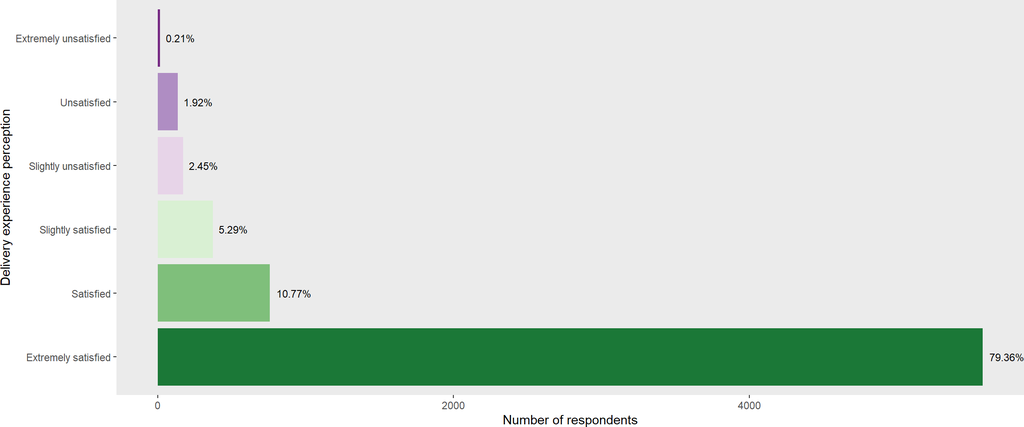

This unsatisfaction could be mostly related with the deliver on time of the products (7.5%) and the date set to provide them (8.2%). Following these features and according to the data, the explanation of what is delivered produces most of the nonconformities.

| **Characteristic** | **N = 7029**<sup>1</sup> |
| --- | --- |
| timely_delivery | 525 (7.5%) |
| cleanliness | 190 (2.7%) |
| condition | 153 (2.2%) |
| features_explanation | 281 (4.0%) |
| delivery_time | 573 (8.2%) |
| scheduling_explanation | 178 (2.5%) |
| checklist_review | 193 (2.7%) |

<sup>*1*</sup> Statistics presented: n (%)

Among the complaints in the delivery phase, problems with the “agencia” (agency), “dia” (day), “tiempo” (time) and the “unidad” (that is, the car). No n-grams displayed a signifivative pattern.

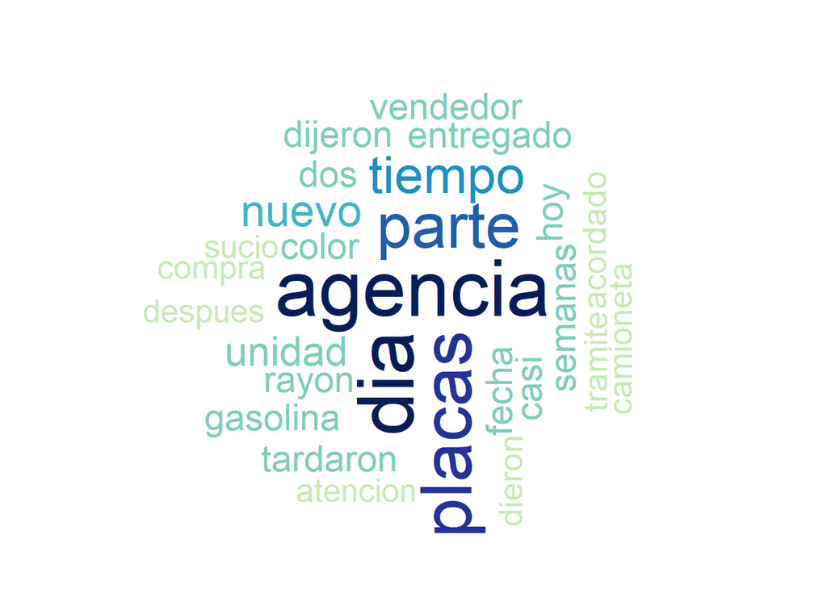

```
##                                              n2
## abril autorizado credito tardo                1
## abril unico malo atencion                     1
## accesorio separamiento parte cajuela          1
## accesorios acordados habian entregado         1
## accesorios cuenta unidad momento              1
## accesorios ejemplo dtect consiste             1
## accesorios minimos indispensables unicamente  1
## accesorios sujeccion caja trasera             1
## acepte trajeron tonta dando                   1
## acepte unidad esperando hablar                1
```

# After sales

After sales service has an important role in customer satisfaction and long term relations between a brand and the people. Similar to the other experiences, people score this moment more than satisfied.

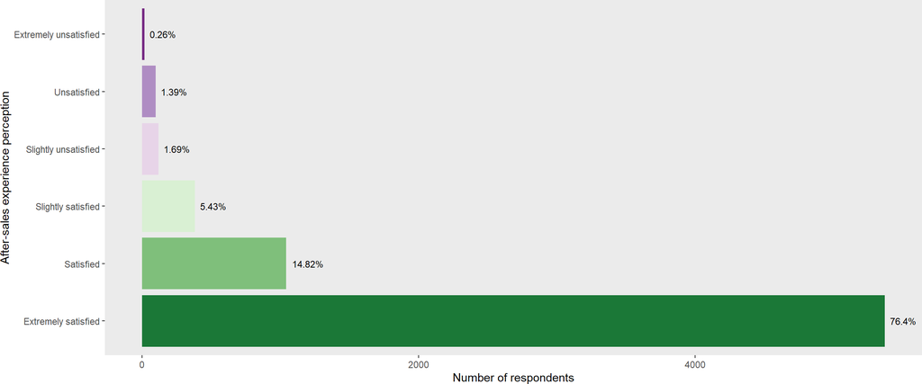

# Conclusion

The customer experience surveys provide overall information and specific concerns about complaints and problems in the different phases within the sales experience. Notwithstanding the positive puntuations throughout the questionary, is possible to highlight concerns about product knowledge, payments and use of time for bringing a product.